# Question 3: “What machine learning models best predict diabetes mellitus based on effectiveness, efficiency, stability, and interpretability?”

## Importing Python libraries and the Initial Dataset

### Importing Python libraries

```python
#%pip install pandas mlxtend matplotlib seaborn
import pandas as pd
import numpy as np
from sklearn.model_selection import train_test_split
from imblearn.over_sampling import SMOTE
from sklearn.model_selection import StratifiedKFold
from sklearn.feature_selection import SelectKBest, chi2
from sklearn.model_selection import GridSearchCV
from sklearn.preprocessing import label_binarize
import matplotlib.pyplot as plt
import seaborn as sns
from sklearn.tree import DecisionTreeClassifier
from sklearn.linear_model import LogisticRegression
from sklearn.naive_bayes import GaussianNB
from sklearn.neighbors import KNeighborsClassifier
import os
from sklearn.metrics import confusion_matrix, classification_report, accuracy_score, recall_score, precision_score, f1_score, fbeta_score, roc_auc_score, roc_curve, auc
```

### Importing the cleaned dataset from desktop folder

```python
def read_csv_file(file_path):
    """
    Read a CSV file into a pandas DataFrame.

    Parameters:
    file_path (str): The path to the CSV file.

    Returns:
    pandas.DataFrame: The DataFrame containing the data from the CSV file.
    """
    # Read the CSV file into a pandas DataFrame
    df = pd.read_csv(file_path)

    return df

# Specify the file path
file_path = 'C:/Users/steph/OneDrive/Desktop/Diabetes/archive/diabetes_012_health_indicators_BRFSS2015_cleaned.csv'

# Read the CSV file into a pandas DataFrame
df = read_csv_file(file_path)

# Display the DataFrame
display(df.head())
```

|  | Diabetes_012 | HighBP | HighChol | CholCheck | BMI | Smoker | Stroke | HeartDiseaseorAttack | PhysActivity | Fruits | ... | AnyHealthcare | NoDocbcCost | GenHlth | MentHlth | PhysHlth | DiffWalk | Sex | Age | Education | Income |
| --- | --- | --- | --- | --- | --- | --- | --- | --- | --- | --- | --- | --- | --- | --- | --- | --- | --- | --- | --- | --- | --- |
| 0 | 0 | 1 | 1 | 1 | 40.0 | 1 | 0 | 0 | 0 | 0 | ... | 1 | 0 | 5 | 18 | 15 | 1 | 0 | 9 | 4 | 3 |
| 1 | 0 | 0 | 0 | 0 | 25.0 | 1 | 0 | 0 | 1 | 0 | ... | 0 | 1 | 3 | 0 | 0 | 0 | 0 | 7 | 6 | 1 |
| 2 | 0 | 1 | 1 | 1 | 28.0 | 0 | 0 | 0 | 0 | 1 | ... | 1 | 1 | 5 | 30 | 30 | 1 | 0 | 9 | 4 | 8 |
| 3 | 0 | 1 | 0 | 1 | 27.0 | 0 | 0 | 0 | 1 | 1 | ... | 1 | 0 | 2 | 0 | 0 | 0 | 0 | 11 | 3 | 6 |
| 4 | 0 | 1 | 1 | 1 | 24.0 | 0 | 0 | 0 | 1 | 1 | ... | 1 | 0 | 2 | 3 | 0 | 0 | 0 | 11 | 5 | 4 |

5 rows × 22 columns

## Prepare Data for Machine Learning Selection

```python
#list column names and data type
df.info()
```

```
<class 'pandas.core.frame.DataFrame'>
RangeIndex: 253680 entries, 0 to 253679
Data columns (total 22 columns):
 #   Column                Non-Null Count   Dtype
---  ------                --------------   -----
 0   Diabetes_012          253680 non-null  int64
 1   HighBP                253680 non-null  int64
 2   HighChol              253680 non-null  int64
 3   CholCheck             253680 non-null  int64
 4   BMI                   253680 non-null  float64
 5   Smoker                253680 non-null  int64
 6   Stroke                253680 non-null  int64
 7   HeartDiseaseorAttack  253680 non-null  int64
 8   PhysActivity          253680 non-null  int64
 9   Fruits                253680 non-null  int64
 10  Veggies               253680 non-null  int64
 11  HvyAlcoholConsump     253680 non-null  int64
 12  AnyHealthcare         253680 non-null  int64
 13  NoDocbcCost           253680 non-null  int64
 14  GenHlth               253680 non-null  int64
 15  MentHlth              253680 non-null  int64
 16  PhysHlth              253680 non-null  int64
 17  DiffWalk              253680 non-null  int64
 18  Sex                   253680 non-null  int64
 19  Age                   253680 non-null  int64
 20  Education             253680 non-null  int64
 21  Income                253680 non-null  int64
dtypes: float64(1), int64(21)
memory usage: 42.6 MB
```

### Convert to appropriate category type (for consistency across all analysis)

```python
#Convert data to appropriate types

#Define nominal YES/NO columns to convert to category type
nominal_columns = ['HighBP', 'HighChol', 'CholCheck', 'Smoker', 'Stroke', 'HeartDiseaseorAttack', 'PhysActivity', 'Fruits', 'Veggies', 'HvyAlcoholConsump', 'AnyHealthcare', 'NoDocbcCost', 'DiffWalk']
#Convert nominal columns to category type
# Convert each nominal column to categorical type
for column in nominal_columns:
    df[column] = pd.Categorical(df[column],
                                 categories=[0, 1],
                                 ordered=False)

#Define FEMALE/MALE categories and labels and convert to category type
df['Sex'] = pd.Categorical(df['Sex'],
    categories=[0,1],
    ordered=False
)

#Define discrete columns to convert to integer type
discrete_columns = ['MentHlth', 'PhysHlth']
#Convert discrete columns to integer type
df[discrete_columns] = df[discrete_columns].astype('int')

# Define ordinal categories with labels and convert to category type
df['Diabetes_012'] = pd.Categorical(df['Diabetes_012'],
    categories=[0, 1, 2],
    ordered=True
)

df['GenHlth'] = pd.Categorical(df['GenHlth'],
    categories=[1, 2, 3, 4, 5],
    ordered=True
)

df['Age'] = pd.Categorical(df['Age'],
    categories=[1, 2, 3, 4, 5, 6, 7, 8, 9, 10, 11, 12, 13],
    ordered=True
)

df['Education'] = pd.Categorical(df['Education'],
    categories=[1, 2, 3, 4, 5, 6],
    ordered=True
)

df['Income'] = pd.Categorical(df['Income'],
    categories=[1, 2, 3, 4, 5, 6, 7, 8],
    ordered=True
)
#Dividing BMI into 6 categories based on CDC guidelines: https://www.cdc.gov/bmi/adult-calculator/bmi-categories.html
#Where 1 = 'Underweight', 2= 'Healthy weight', 3= 'Overweight', 4= 'Class 1 Obesity', 5 = 'Class 2 Obesity', 6 = 'Class 3 Obesity'])
df['BMI'] = pd.cut(df['BMI'], bins=[0, 18.4, 24.9, 29.9, 34.9, 39.9, 100], labels=[1, 2, 3, 4, 5, 6])

# Dividing MentHlth into 7 categories where the first category is for containing 0 only and the last category goes up to 30
# Where 0 = '0', 1 = '1-5', 2 ='6-10', 3 = '11-15', 4 = '16-20', 5 = '21-25', 6 = '26-30']
df['MentHlth'] = pd.cut(df['MentHlth'], bins=[-1, 0, 5, 10, 15, 20, 25, 30], labels=[0, 1, 2, 3, 4, 5, 6])

#Dividing PhysHlth into 7 categories where the first category is for containing 0 only and the last category goes up to 30
# Where 0 = '0', 1 = '1-5', 2 ='6-10', 3 = '11-15', 4 = '16-20', 5 = '21-25', 6 = '26-30']
df['PhysHlth'] = pd.cut(df['PhysHlth'], bins=[-1, 0, 5, 10, 15, 20, 25, 30], labels=[0, 1, 2, 3, 4, 5, 6])
```

```python
#check data types
df.info()
```

```
<class 'pandas.core.frame.DataFrame'>
RangeIndex: 253680 entries, 0 to 253679
Data columns (total 22 columns):
 #   Column                Non-Null Count   Dtype
---  ------                --------------   -----
 0   Diabetes_012          253680 non-null  category
 1   HighBP                253680 non-null  category
 2   HighChol              253680 non-null  category
 3   CholCheck             253680 non-null  category
 4   BMI                   253680 non-null  category
 5   Smoker                253680 non-null  category
 6   Stroke                253680 non-null  category
 7   HeartDiseaseorAttack  253680 non-null  category
 8   PhysActivity          253680 non-null  category
 9   Fruits                253680 non-null  category
 10  Veggies               253680 non-null  category
 11  HvyAlcoholConsump     253680 non-null  category
 12  AnyHealthcare         253680 non-null  category
 13  NoDocbcCost           253680 non-null  category
 14  GenHlth               253680 non-null  category
 15  MentHlth              253680 non-null  category
 16  PhysHlth              253680 non-null  category
 17  DiffWalk              253680 non-null  category
 18  Sex                   253680 non-null  category
 19  Age                   253680 non-null  category
 20  Education             253680 non-null  category
 21  Income                253680 non-null  category
dtypes: category(22)
memory usage: 5.3 MB
```

### Drop Duplicate values

```python
#Drop duplicat values
df = df.drop_duplicates()
print(df.shape)
```

```
(202619, 22)
```

```python
#Check for duplicate values
duplicate = df.duplicated()
print(duplicate.sum())
```

```
0
```

## Split Data into Train and Test sets

```python
#Split the data into train and test set where Diabetes_012 is the target variable
X = df.drop('Diabetes_012', axis=1)
y = df['Diabetes_012']

#Split the data into train and test set
X_train, X_test, y_train, y_test = train_test_split(X, y, test_size=0.2, random_state=42)

#Check the shape of the train and test set
print(X_train.shape, X_test.shape)
```

```
(162095, 21) (40524, 21)
```

```python
#Check the shape of the target variable in the train set
y_train.value_counts()
```

```
Diabetes_012
0    131150
2     27328
1      3617
Name: count, dtype: int64
```

## Balance the Train Set using SMOTE (Synthetic Minority Over-sampling Technique)

The severe class imbalance can lead to biased and misleading performance metrics when checking for validity and generalizability of on the test set. The class imbalance also also affects feature selection on models that rely on the variability of the data. Using SMOTE creates synthetic samples rather than duplicating existing samples.

```python
#Oversample(res - resampled) the minority class using SMOTE technique on the X_train and y_train data
smote = SMOTE(random_state=42)
X_train, y_train = smote.fit_resample(X_train, y_train)

#Check the shape of the target variable in the train set
y_train.value_counts()
```

```
Diabetes_012
0    131150
1    131150
2    131150
Name: count, dtype: int64
```

Apply the best feature selection model from Question 2 (Logistic Regression)

```python
final_lr_model = LogisticRegression(multi_class='multinomial', solver='lbfgs', C=0.01, penalty='l2')
final_lr_model.fit(X_train, y_train)
```

```
LogisticRegression(C=0.01, multi_class='multinomial')
```

### Get the top features based on coefficients

```python
# Get the coefficients from the fitted logistic regression model
coefficients = final_lr_model.coef_

# Compute the absolute values of the coefficients (since we're looking for importance)
importance = np.abs(coefficients).mean(axis=0)  # Mean importance across all classes (for multiclass)

# Get indices of the top 10 most important features based on the coefficients
top_features_idx = np.argsort(importance)[-10:]  # Get indices of top 10 features

# Now, use X_train's columns for the selected feature names
selected_features = X_train.columns[top_features_idx]  # Get the feature names

# Display the selected feature names in order of importance with their corresponding coefficients
feature_importance = pd.DataFrame({'Feature': selected_features, 'Importance': importance[top_features_idx]})
feature_importance = feature_importance.sort_values(by='Importance', ascending=False)
display(feature_importance)
```

|  | Feature | Importance |
| --- | --- | --- |
| 9 | HvyAlcoholConsump | 0.994250 |
| 8 | Stroke | 0.596465 |
| 7 | NoDocbcCost | 0.418181 |
| 6 | CholCheck | 0.347710 |
| 5 | HeartDiseaseorAttack | 0.316498 |
| 4 | HighBP | 0.246620 |
| 3 | AnyHealthcare | 0.219924 |
| 2 | Smoker | 0.204647 |
| 1 | HighChol | 0.174169 |
| 0 | Sex | 0.169546 |

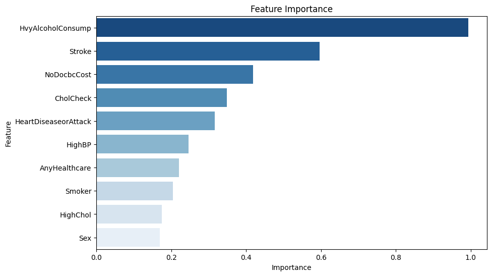

```python
#Visualize the feature importance
plt.figure(figsize=(10, 6))
sns.barplot(x='Importance', y='Feature', data=feature_importance, palette='Blues_r')
plt.title('Feature Importance')
plt.xlabel('Importance')
plt.ylabel('Feature')
plt.show()
```

### Create a Training set and a Test Set that only contains the top 10 features as identified by the feature selection

```python
# Create the DataFrame with the selected features
X_train_selected = X_train.iloc[:, top_features_idx]

# Transform the test set to have only the selected features
# X_test is also a DataFrame, so we can use .iloc to select columns by index
X_test_selected = X_test.iloc[:, top_features_idx]

# Check the shape of the selected features
print(X_train_selected.shape, X_test_selected.shape)
```

```
(393450, 10) (40524, 10)
```

## Initiate K-fold Cross-Validation and Train Machine Learning Models for Diabetes Prediction on Each Fold of the Transformed Training Set

```python
# Initialize StratifiedKFold
kf = StratifiedKFold(n_splits=5, shuffle=True, random_state=42)

# Initialize lists to store metrics across folds for each model
accuracies_dt = []
f1_scores_dt = []
f2_scores_dt = []
precisions_dt = []
recalls_dt = []
roc_auc_scores_dt = []
confusion_matrices_dt = []

accuracies_lr = []
f1_scores_lr = []
f2_scores_lr = []
precisions_lr = []
recalls_lr = []
roc_auc_scores_lr = []
confusion_matrices_lr = []

accuracies_nb = []
f1_scores_nb = []
f2_scores_nb = []
precisions_nb = []
recalls_nb = []
roc_auc_scores_nb = []
confusion_matrices_nb = []

accuracies_knn = []
f1_scores_knn = []
f2_scores_knn = []
precisions_knn = []
recalls_knn = []
roc_auc_scores_knn = []
confusion_matrices_knn = []

# Loop over each fold
for train_index, val_index in kf.split(X_train_selected, y_train):
    # Get the training and validation data for each fold
    X_train_fold, X_val_fold = X_train_selected.iloc[train_index], X_train_selected.iloc[val_index]
    y_train_fold, y_val_fold = y_train.iloc[train_index], y_train.iloc[val_index]

    # 1. Train Decision Tree model
    dt_model = DecisionTreeClassifier(random_state=42)
    dt_model.fit(X_train_fold, y_train_fold)
    dt_pred = dt_model.predict(X_val_fold)

    # Store metrics for Decision Tree
    accuracies_dt.append(accuracy_score(y_val_fold, dt_pred))
    class_report_dt = classification_report(y_val_fold, dt_pred, output_dict=True)
    precisions_dt.append(class_report_dt['macro avg']['precision'])
    recalls_dt.append(class_report_dt['macro avg']['recall'])
    f1_scores_dt.append(class_report_dt['macro avg']['f1-score'])
    f2_scores_dt.append(fbeta_score(y_val_fold, dt_pred, beta=2, average='macro'))
    roc_auc_scores_dt.append(roc_auc_score(label_binarize(y_val_fold, classes=[0, 1, 2]), label_binarize(dt_pred, classes=[0, 1, 2]), average='macro'))
    confusion_matrices_dt.append(confusion_matrix(y_val_fold, dt_pred))

    # 2. Train Multinomial Logistic Regression model
    lr_model = LogisticRegression(multi_class='multinomial', solver='lbfgs', C=0.01, penalty='l2')
    lr_model.fit(X_train_fold, y_train_fold)
    lr_pred = lr_model.predict(X_val_fold)

    # Store metrics for Logistic Regression
    accuracies_lr.append(accuracy_score(y_val_fold, lr_pred))
    class_report_lr = classification_report(y_val_fold, lr_pred, output_dict=True)
    precisions_lr.append(class_report_lr['macro avg']['precision'])
    recalls_lr.append(class_report_lr['macro avg']['recall'])
    f1_scores_lr.append(class_report_lr['macro avg']['f1-score'])
    f2_scores_lr.append(fbeta_score(y_val_fold, lr_pred, beta=2, average='macro'))
    roc_auc_scores_lr.append(roc_auc_score(label_binarize(y_val_fold, classes=[0, 1, 2]), label_binarize(lr_pred, classes=[0, 1, 2]), average='macro'))
    confusion_matrices_lr.append(confusion_matrix(y_val_fold, lr_pred))

    # 3. Train Gaussian Naive Bayes model
    nb_model = GaussianNB()
    nb_model.fit(X_train_fold, y_train_fold)
    nb_pred = nb_model.predict(X_val_fold)

    # Store metrics for Naive Bayes
    accuracies_nb.append(accuracy_score(y_val_fold, nb_pred))
    class_report_nb = classification_report(y_val_fold, nb_pred, output_dict=True)
    precisions_nb.append(class_report_nb['macro avg']['precision'])
    recalls_nb.append(class_report_nb['macro avg']['recall'])
    f1_scores_nb.append(class_report_nb['macro avg']['f1-score'])
    f2_scores_nb.append(fbeta_score(y_val_fold, nb_pred, beta=2, average='macro'))
    roc_auc_scores_nb.append(roc_auc_score(label_binarize(y_val_fold, classes=[0, 1, 2]), label_binarize(nb_pred, classes=[0, 1, 2]), average='macro'))
    confusion_matrices_nb.append(confusion_matrix(y_val_fold, nb_pred))

    # 4. Train K-Nearest Neighbors model
    knn_model = KNeighborsClassifier()
    knn_model.fit(X_train_fold, y_train_fold)
    knn_pred = knn_model.predict(X_val_fold)

    # Store metrics for K-Nearest Neighbors
    accuracies_knn.append(accuracy_score(y_val_fold, knn_pred))
    class_report_knn = classification_report(y_val_fold, knn_pred, output_dict=True)
    precisions_knn.append(class_report_knn['macro avg']['precision'])
    recalls_knn.append(class_report_knn['macro avg']['recall'])
    f1_scores_knn.append(class_report_knn['macro avg']['f1-score'])
    f2_scores_knn.append(fbeta_score(y_val_fold, knn_pred, beta=2, average='macro'))
    roc_auc_scores_knn.append(roc_auc_score(label_binarize(y_val_fold, classes=[0, 1, 2]), label_binarize(knn_pred, classes=[0, 1, 2]), average='macro'))
    confusion_matrices_knn.append(confusion_matrix(y_val_fold, knn_pred))
```

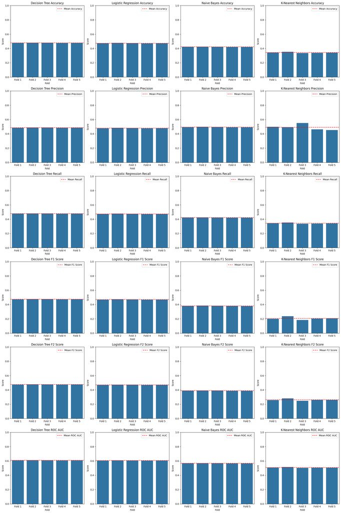

```python
# Visualize results for each k-fold for each model

# Define the metrics to visualize
metrics = ['Accuracy', 'Precision', 'Recall', 'F1 Score', 'F2 Score', 'ROC AUC']

# Define the models to visualize
models = ['Decision Tree', 'Logistic Regression', 'Naive Bayes', 'K-Nearest Neighbors']

# Define the lists of metrics for each model
accuracies = [accuracies_dt, accuracies_lr, accuracies_nb, accuracies_knn]
precisions = [precisions_dt, precisions_lr, precisions_nb, precisions_knn]
recalls = [recalls_dt, recalls_lr, recalls_nb, recalls_knn]
f1_scores = [f1_scores_dt, f1_scores_lr, f1_scores_nb, f1_scores_knn]
f2_scores = [f2_scores_dt, f2_scores_lr, f2_scores_nb, f2_scores_knn]
roc_auc_scores = [roc_auc_scores_dt, roc_auc_scores_lr, roc_auc_scores_nb, roc_auc_scores_knn]

# Create a figure with subplots (7 rows for metrics, 4 columns for models)
fig, axes = plt.subplots(6, 4, figsize=(20, 30))

# Loop over each metric
for i, metric in enumerate(metrics):
    # Loop over each model
    for j, model in enumerate(models):
        # Get the list of scores for the current model based on the metric
        if metric == 'Accuracy':
            scores = accuracies[j]
        elif metric == 'Precision':
            scores = precisions[j]
        elif metric == 'Recall':
            scores = recalls[j]
        elif metric == 'F1 Score':
            scores = f1_scores[j]
        elif metric == 'F2 Score':
            scores = f2_scores[j]
        elif metric == 'ROC AUC':
            scores = roc_auc_scores[j]

        # Plot the scores for the current model
        sns.barplot(x=[f'Fold {k+1}' for k in range(len(scores))], y=scores, ax=axes[i, j])
        axes[i, j].set_title(f'{model} {metric}')
        axes[i, j].set_ylim(0, 1)
        axes[i, j].set_ylabel('Score')
        axes[i, j].set_xlabel('Fold')
        axes[i, j].axhline(np.mean(scores), color='red', linestyle='--', label=f'Mean {metric}')
        axes[i, j].legend()

# Adjust the layout
plt.tight_layout()
plt.show()
```

### Display Aggregate results for evaluation metrics

```python
#Display aggregate results for evaluation metrics of each model
def aggregate_results(metrics):
    return {
        'mean': np.mean(metrics),
        'std': np.std(metrics)
    }

# Aggregate results for Decision Tree
dt_results = {
    'accuracy': aggregate_results(accuracies_dt),
    'precision': aggregate_results(precisions_dt),
    'recall': aggregate_results(recalls_dt),
    'f1-score': aggregate_results(f1_scores_dt),
    'f2-score': aggregate_results(f2_scores_dt),
    'roc_auc': aggregate_results(roc_auc_scores_dt)
}

# Aggregate results for Multinomial Logistic Regression
lr_results = {
    'accuracy': aggregate_results(accuracies_lr),
    'precision': aggregate_results(precisions_lr),
    'recall': aggregate_results(recalls_lr),
    'f1-score': aggregate_results(f1_scores_lr),
    'f2-score': aggregate_results(f2_scores_dt),
    'roc_auc': aggregate_results(roc_auc_scores_lr)
}

# Aggregate results for Gaussian Naive Bayes
nb_results = {
    'accuracy': aggregate_results(accuracies_nb),
    'precision': aggregate_results(precisions_nb),
    'recall': aggregate_results(recalls_nb),
    'f1-score': aggregate_results(f1_scores_nb),
    'f2-score': aggregate_results(f2_scores_dt),
    'roc_auc': aggregate_results(roc_auc_scores_nb)
}

# Aggregate results for K-Nearest Neighbors
knn_results = {
    'accuracy': aggregate_results(accuracies_knn),
    'precision': aggregate_results(precisions_knn),
    'recall': aggregate_results(recalls_knn),
    'f1-score': aggregate_results(f1_scores_knn),
    'f2-score': aggregate_results(f2_scores_dt),
    'roc_auc': aggregate_results(roc_auc_scores_knn)
}

# Display the aggregate results for each model
print('Decision Tree Results:')
print(dt_results)
print('\nMultinomial Logistic Regression Results:')
print(lr_results)
print('\nGaussian Naive Bayes Results:')
print(nb_results)
print('\nK-Nearest Neighbors Results:')
print(knn_results)
```

[output not shown]

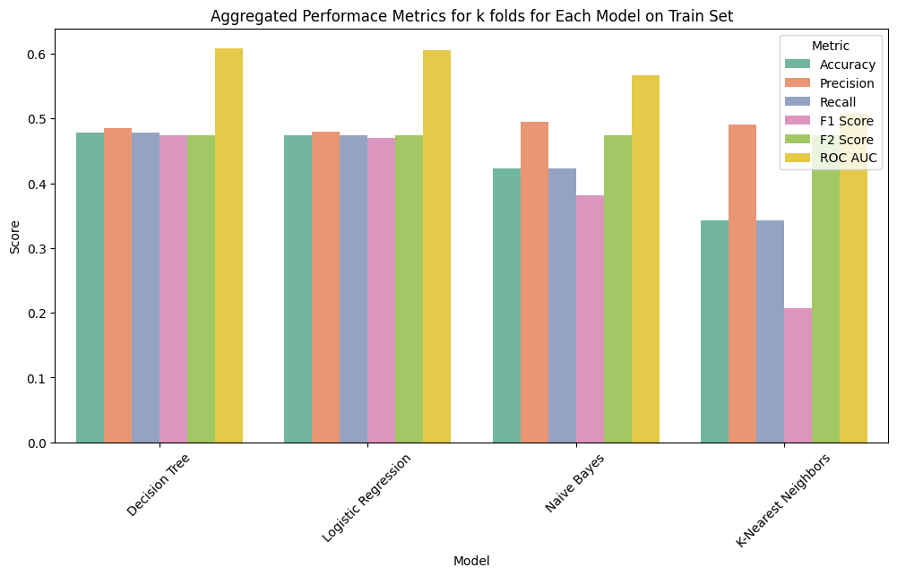

```python
#Visualize the evaluation_df where there is one bar per model per metric but all bars are on the same chart
# Initialize the evaluation DataFrame
evaluation_df_trainset = pd.DataFrame({
    'Model': ['Decision Tree', 'Logistic Regression', 'Naive Bayes', 'K-Nearest Neighbors'],
    'Accuracy': [dt_results['accuracy']['mean'], lr_results['accuracy']['mean'], nb_results['accuracy']['mean'], knn_results['accuracy']['mean']],
    'Precision': [dt_results['precision']['mean'], lr_results['precision']['mean'], nb_results['precision']['mean'], knn_results['precision']['mean']],
    'Recall': [dt_results['recall']['mean'], lr_results['recall']['mean'], nb_results['recall']['mean'], knn_results['recall']['mean']],
    'F1 Score': [dt_results['f1-score']['mean'], lr_results['f1-score']['mean'], nb_results['f1-score']['mean'], knn_results['f1-score']['mean']],
    'F2 Score': [dt_results['f2-score']['mean'], lr_results['f2-score']['mean'], nb_results['f2-score']['mean'], knn_results['f2-score']['mean']],
    'ROC AUC': [dt_results['roc_auc']['mean'], lr_results['roc_auc']['mean'], nb_results['roc_auc']['mean'], knn_results['roc_auc']['mean']]
})

# Melt the DataFrame to 'long' format
evaluation_df_melted_trainset = evaluation_df_trainset.melt(id_vars='Model', var_name='Metric', value_name='Score')

# Plot the evaluation results
plt.figure(figsize=(12, 6))
sns.barplot(x='Model', y='Score', hue='Metric', data=evaluation_df_melted_trainset, palette='Set2')
plt.title('Aggregated Performace Metrics for k folds for Each Model on Train Set')
plt.ylabel('Score')
plt.xticks(rotation=45)
plt.legend(title='Metric')
# Show the plot
plt.show()
```

```python
display(evaluation_df_trainset)
```

[output not shown]

## Select best hyperparameters for each model

### Select Hyperparameters for decision tree

```python
# Apply cross validation and grid search to find the best hyperparameters for the Decision Tree model
param_grid_dt = {
    'criterion': ['gini', 'entropy'],
    'max_depth': [5, 10, 15, 20, 25],
    'min_samples_split': [2, 5, 10, 15, 20],
    'min_samples_leaf': [1, 2, 5, 10, 15]
}

# Initialize the Decision Tree model
dt_model = DecisionTreeClassifier(random_state=42)

# Initialize GridSearchCV
grid_search_dt = GridSearchCV(estimator=dt_model, param_grid=param_grid_dt, cv=kf, scoring='f1_macro')

# Fit the GridSearchCV object on the training data
grid_search_dt.fit(X_train_selected, y_train)

# Get the best hyperparameters from the GridSearchCV object
best_params_dt = grid_search_dt.best_params_
print("Best parameters for Decision Tree:", best_params_dt)
```

```
Best parameters for Decision Tree: {'criterion': 'gini', 'max_depth': 10, 'min_samples_leaf': 1, 'min_samples_split': 10}
```

### Select Hyperparameters for Multinomial Logistic Regression

```python
# Apply cross validation and grid search to find the best hyperparameters for the Multinomial Logistic Regression model
param_grid_lr = {
    'C': [0.001, 0.01, 0.1, 1, 10],
    'penalty': ['l1', 'l2']
}

# Initialize the Multinomial Logistic Regression model
lr_model = LogisticRegression(multi_class='multinomial', solver='lbfgs', random_state=42)

# Initialize GridSearchCV
grid_search_lr = GridSearchCV(estimator=lr_model, param_grid=param_grid_lr, cv=kf, scoring='f1_macro')

# Fit the GridSearchCV object on the training data
grid_search_lr.fit(X_train_selected, y_train)

# Get the best hyperparameters from the GridSearchCV object
best_params_lr = grid_search_lr.best_params_
print("Best parameters for Logistic Regression:", best_params_lr)
```

[output not shown]

[output cut: 51 more lines]

[output not shown]